# Project: Investigate a Dataset ([TMDb Movie Data](https://www.google.com/url?q=https://d17h27t6h515a5.cloudfront.net/topher/2017/October/59dd1c4c_tmdb-movies/tmdb-movies.csv&sa=D&ust=1510938699779000&usg=AFQjCNEhCPgwHa9F0nFQ8g3mGI0qQSncxg))

# MONARK PAWAR on 15-07-2020

- Introduction
- Data Wrangling
- Exploratory Data Analysis
- Conclusions

## Introduction

#### Dataset

> I choose the TMDb movie data set for data analysis. This data set contains information about 10,000 movies collected from The Movie Database (TMDb), including user ratings and revenue.I would like to find other intresting patterns in the dataset.

## Approach

1.Preview and clean the data.

> Remove unnecessary information that are not useful for analysis Inspection for any null and duplicated values Change data types if needed

2.Explore the data and draw conclusion to answer questions.

> Study the stats to find meaningful information. Group and filter certain data to find important patterns Plot above data and make visualization to show the results.

#### Question

> 1.Which movies are the most profitable to the market?

> 2.Which movies have the most and least profit, budget and runtime?

> 3.How does popularity affect the profit?

> 4.Which years do movies made the most profits?

> 5.Average Runtime Of Movies From Year To Year?

> 6.Which Genre Has The Highest Release Of Movies?

```python
# Import all libraries
import pandas as pd
import numpy as np
import matplotlib.pyplot as plt
%matplotlib inline
import seaborn as sns
sns.set_style('darkgrid')
```

## Data Wrangling

### General Properties

```python
# Load your data and print out a few lines. Perform operations to inspect data
#   types and look for instances of missing or possibly errant data.

df = pd.read_csv('TMDb Data.csv')
df.head(5)
```

|  | id | imdb_id | popularity | budget | revenue | original_title | cast | homepage | director | tagline | ... | overview | runtime | genres | production_companies | release_date | vote_count | vote_average | release_year | budget_adj | revenue_adj |
| --- | --- | --- | --- | --- | --- | --- | --- | --- | --- | --- | --- | --- | --- | --- | --- | --- | --- | --- | --- | --- | --- |
| 0 | 135397 | tt0369610 | 32.985763 | 150000000 | 1513528810 | Jurassic World | Chris Pratt\|Bryce Dallas Howard\|Irrfan Khan\|Vi... | http://www.jurassicworld.com/ | Colin Trevorrow | The park is open. | ... | Twenty-two years after the events of Jurassic ... | 124 | Action\|Adventure\|Science Fiction\|Thriller | Universal Studios\|Amblin Entertainment\|Legenda... | 6/9/15 | 5562 | 6.5 | 2015 | 1.379999e+08 | 1.392446e+09 |
| 1 | 76341 | tt1392190 | 28.419936 | 150000000 | 378436354 | Mad Max: Fury Road | Tom Hardy\|Charlize Theron\|Hugh Keays-Byrne\|Nic... | http://www.madmaxmovie.com/ | George Miller | What a Lovely Day. | ... | An apocalyptic story set in the furthest reach... | 120 | Action\|Adventure\|Science Fiction\|Thriller | Village Roadshow Pictures\|Kennedy Miller Produ... | 5/13/15 | 6185 | 7.1 | 2015 | 1.379999e+08 | 3.481613e+08 |
| 2 | 262500 | tt2908446 | 13.112507 | 110000000 | 295238201 | Insurgent | Shailene Woodley\|Theo James\|Kate Winslet\|Ansel... | http://www.thedivergentseries.movie/#insurgent | Robert Schwentke | One Choice Can Destroy You | ... | Beatrice Prior must confront her inner demons ... | 119 | Adventure\|Science Fiction\|Thriller | Summit Entertainment\|Mandeville Films\|Red Wago... | 3/18/15 | 2480 | 6.3 | 2015 | 1.012000e+08 | 2.716190e+08 |
| 3 | 140607 | tt2488496 | 11.173104 | 200000000 | 2068178225 | Star Wars: The Force Awakens | Harrison Ford\|Mark Hamill\|Carrie Fisher\|Adam D... | http://www.starwars.com/films/star-wars-episod... | J.J. Abrams | Every generation has a story. | ... | Thirty years after defeating the Galactic Empi... | 136 | Action\|Adventure\|Science Fiction\|Fantasy | Lucasfilm\|Truenorth Productions\|Bad Robot | 12/15/15 | 5292 | 7.5 | 2015 | 1.839999e+08 | 1.902723e+09 |
| 4 | 168259 | tt2820852 | 9.335014 | 190000000 | 1506249360 | Furious 7 | Vin Diesel\|Paul Walker\|Jason Statham\|Michelle ... | http://www.furious7.com/ | James Wan | Vengeance Hits Home | ... | Deckard Shaw seeks revenge against Dominic Tor... | 137 | Action\|Crime\|Thriller | Universal Pictures\|Original Film\|Media Rights ... | 4/1/15 | 2947 | 7.3 | 2015 | 1.747999e+08 | 1.385749e+09 |

5 rows × 21 columns

First step is to assess the dataset structure to gather the basic information about the data we are dealing with

```python
df.info()
```

```
<class 'pandas.core.frame.DataFrame'>
RangeIndex: 10866 entries, 0 to 10865
Data columns (total 21 columns):
 #   Column                Non-Null Count  Dtype
---  ------                --------------  -----
 0   id                    10866 non-null  int64
 1   imdb_id               10856 non-null  object
 2   popularity            10866 non-null  float64
 3   budget                10866 non-null  int64
 4   revenue               10866 non-null  int64
 5   original_title        10866 non-null  object
 6   cast                  10790 non-null  object
 7   homepage              2936 non-null   object
 8   director              10822 non-null  object
 9   tagline               8042 non-null   object
 10  keywords              9373 non-null   object
 11  overview              10862 non-null  object
 12  runtime               10866 non-null  int64
 13  genres                10843 non-null  object
 14  production_companies  9836 non-null   object
 15  release_date          10866 non-null  object
 16  vote_count            10866 non-null  int64
 17  vote_average          10866 non-null  float64
 18  release_year          10866 non-null  int64
 19  budget_adj            10866 non-null  float64
 20  revenue_adj           10866 non-null  float64
dtypes: float64(4), int64(6), object(11)
memory usage: 1.7+ MB
```

```python
# Preview stats for each columns
df.describe()
```

|  | id | popularity | budget | revenue | runtime | vote_count | vote_average | release_year | budget_adj | revenue_adj |
| --- | --- | --- | --- | --- | --- | --- | --- | --- | --- | --- |
| count | 10866.000000 | 10866.000000 | 1.086600e+04 | 1.086600e+04 | 10866.000000 | 10866.000000 | 10866.000000 | 10866.000000 | 1.086600e+04 | 1.086600e+04 |
| mean | 66064.177434 | 0.646441 | 1.462570e+07 | 3.982332e+07 | 102.070863 | 217.389748 | 5.974922 | 2001.322658 | 1.755104e+07 | 5.136436e+07 |
| std | 92130.136561 | 1.000185 | 3.091321e+07 | 1.170035e+08 | 31.381405 | 575.619058 | 0.935142 | 12.812941 | 3.430616e+07 | 1.446325e+08 |
| min | 5.000000 | 0.000065 | 0.000000e+00 | 0.000000e+00 | 0.000000 | 10.000000 | 1.500000 | 1960.000000 | 0.000000e+00 | 0.000000e+00 |
| 25% | 10596.250000 | 0.207583 | 0.000000e+00 | 0.000000e+00 | 90.000000 | 17.000000 | 5.400000 | 1995.000000 | 0.000000e+00 | 0.000000e+00 |
| 50% | 20669.000000 | 0.383856 | 0.000000e+00 | 0.000000e+00 | 99.000000 | 38.000000 | 6.000000 | 2006.000000 | 0.000000e+00 | 0.000000e+00 |
| 75% | 75610.000000 | 0.713817 | 1.500000e+07 | 2.400000e+07 | 111.000000 | 145.750000 | 6.600000 | 2011.000000 | 2.085325e+07 | 3.369710e+07 |
| max | 417859.000000 | 32.985763 | 4.250000e+08 | 2.781506e+09 | 900.000000 | 9767.000000 | 9.200000 | 2015.000000 | 4.250000e+08 | 2.827124e+09 |

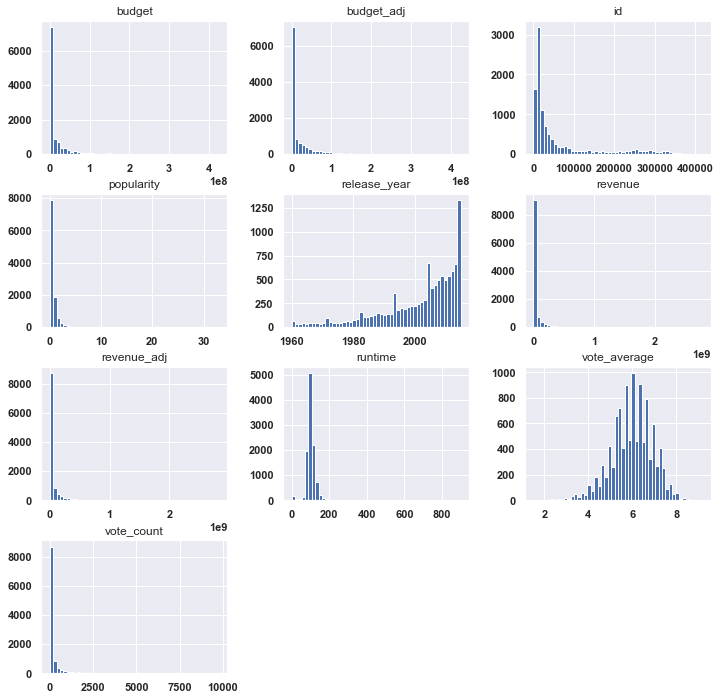

```python
# Preview overall distribution of data from each properties
df.hist(figsize = (12,12), bins=50);
```

```python
# Delete unnecessary columns
df.drop(['id', 'imdb_id','budget_adj', 'revenue_adj', 'homepage', 'keywords', 'tagline',
                              'overview', 'production_companies', 'vote_count', 'vote_average'], axis=1, inplace=True)
```

```python
df.shape
```

```
(10866, 10)
```

```python
# Changing Release_date from string to datetime format, and change budget and revneue to integer
df['release_date'] = pd.to_datetime(df['release_date'])
df['budget'] = df['budget'].astype(int)
df['revenue'] = df['revenue'].astype(int)
df['popularity'] = df['popularity'].astype(int)
```

#### Check for duplicated values

```python
df.duplicated().sum()
```

```
1
```

```python
# drop duplicates
df = df.drop_duplicates(keep=False)
df.duplicated().sum()
```

```
0
```

```python
#### Check for Missing values
df.isnull().sum()
```

```
popularity         0
budget             0
revenue            0
original_title     0
cast              76
director          44
runtime            0
genres            23
release_date       0
release_year       0
dtype: int64
```

```python
# Fill the null values with zero. Check again

df.fillna(0, inplace = True)
```

```python
#Drop rows with zero values in budget and revenue

df['budget'] = df['budget'].replace(0, np.NaN)
df['revenue'] = df['revenue'].replace(0, np.NaN)

df.dropna(inplace =True)
```

```python
# Checking for values to be removed
print(df.isnull().sum())
print(df.duplicated().sum())
```

```
popularity        0
budget            0
revenue           0
original_title    0
cast              0
director          0
runtime           0
genres            0
release_date      0
release_year      0
dtype: int64
0
```

## Exploratory Data Analysis

### Research Question 1 (Which movies are the most profitable to the market?)

```python
# Create new column for the profit to find out which movie is more successful. Make sure it is in integer datatype

df['profit'] = df['revenue'] - df['budget']
df['revenue'] = df['revenue'].astype(int)
df.head(1)
```

|  | popularity | budget | revenue | original_title | cast | director | runtime | genres | release_date | release_year | profit |
| --- | --- | --- | --- | --- | --- | --- | --- | --- | --- | --- | --- |
| 0 | 32 | 150000000.0 | 1513528810 | Jurassic World | Chris Pratt\|Bryce Dallas Howard\|Irrfan Khan\|Vi... | Colin Trevorrow | 124 | Action\|Adventure\|Science Fiction\|Thriller | 2015-06-09 | 2015 | 1.363529e+09 |

```python
# Sort the data by profit and show the top 10 rows.

df.sort_values(['profit'], ascending = False).head(10)
```

|  | popularity | budget | revenue | original_title | cast | director | runtime | genres | release_date | release_year | profit |
| --- | --- | --- | --- | --- | --- | --- | --- | --- | --- | --- | --- |
| 3 | 11 | 200000000.0 | 2068178225 | Star Wars: The Force Awakens | Harrison Ford\|Mark Hamill\|Carrie Fisher\|Adam D... | J.J. Abrams | 136 | Action\|Adventure\|Science Fiction\|Fantasy | 2015-12-15 | 2015 | 1.868178e+09 |
| 5231 | 4 | 200000000.0 | 1845034188 | Titanic | Kate Winslet\|Leonardo DiCaprio\|Frances Fisher\|... | James Cameron | 194 | Drama\|Romance\|Thriller | 1997-11-18 | 1997 | 1.645034e+09 |
| 0 | 32 | 150000000.0 | 1513528810 | Jurassic World | Chris Pratt\|Bryce Dallas Howard\|Irrfan Khan\|Vi... | Colin Trevorrow | 124 | Action\|Adventure\|Science Fiction\|Thriller | 2015-06-09 | 2015 | 1.363529e+09 |
| 4 | 9 | 190000000.0 | 1506249360 | Furious 7 | Vin Diesel\|Paul Walker\|Jason Statham\|Michelle ... | James Wan | 137 | Action\|Crime\|Thriller | 2015-04-01 | 2015 | 1.316249e+09 |
| 4361 | 7 | 220000000.0 | 1519557910 | The Avengers | Robert Downey Jr.\|Chris Evans\|Mark Ruffalo\|Chr... | Joss Whedon | 143 | Science Fiction\|Action\|Adventure | 2012-04-25 | 2012 | 1.299558e+09 |
| 3374 | 5 | 125000000.0 | 1327817822 | Harry Potter and the Deathly Hallows: Part 2 | Daniel Radcliffe\|Rupert Grint\|Emma Watson\|Alan... | David Yates | 130 | Adventure\|Family\|Fantasy | 2011-07-07 | 2011 | 1.202818e+09 |
| 14 | 5 | 280000000.0 | 1405035767 | Avengers: Age of Ultron | Robert Downey Jr.\|Chris Hemsworth\|Mark Ruffalo... | Joss Whedon | 141 | Action\|Adventure\|Science Fiction | 2015-04-22 | 2015 | 1.125036e+09 |
| 5422 | 6 | 150000000.0 | 1274219009 | Frozen | Kristen Bell\|Idina Menzel\|Jonathan Groff\|Josh ... | Chris Buck\|Jennifer Lee | 102 | Animation\|Adventure\|Family | 2013-11-27 | 2013 | 1.124219e+09 |
| 8094 | 1 | 22000000.0 | 1106279658 | The Net | Sandra Bullock\|Jeremy Northam\|Dennis Miller\|We... | Irwin Winkler | 114 | Crime\|Drama\|Mystery\|Thriller\|Action | 1995-07-28 | 1995 | 1.084280e+09 |
| 8 | 7 | 74000000.0 | 1156730962 | Minions | Sandra Bullock\|Jon Hamm\|Michael Keaton\|Allison... | Kyle Balda\|Pierre Coffin | 91 | Family\|Animation\|Adventure\|Comedy | 2015-06-17 | 2015 | 1.082731e+09 |

Above are top 10 movies with the most earned profit. Clearly these titles are well knowed. Star Wars:The Force Awakens is at tops 1, which profit exceded way more than the following movies.

# Question 2. Which movies have the most and least profit, budget and runtime?

```python
# Define a function to find the maximum and minimun of movies from each categories.
def max_min_data(column_name):

    # Find the max from the index number in the column, store to df
    highest_movie = df[column_name].idxmax()
    highest_df = pd.DataFrame(df.loc[highest_movie])

    # Find the min from the index number in the column, store to df
    lowest_movie = df[column_name].idxmin()
    lowest_df = pd.DataFrame(df.loc[lowest_movie])

    #concatenating two dfs
    max_min_data = pd.concat([highest_df, lowest_df], axis = 1)

    return max_min_data


max_min_data('profit')
```

|  | 3 | 1386 |
| --- | --- | --- |
| popularity | 11 | 9 |
| budget | 2e+08 | 2.37e+08 |
| revenue | 2068178225 | -1513461449 |
| original_title | Star Wars: The Force Awakens | Avatar |
| cast | Harrison Ford\|Mark Hamill\|Carrie Fisher\|Adam D... | Sam Worthington\|Zoe Saldana\|Sigourney Weaver\|S... |
| director | J.J. Abrams | James Cameron |
| runtime | 136 | 162 |
| genres | Action\|Adventure\|Science Fiction\|Fantasy | Action\|Adventure\|Fantasy\|Science Fiction |
| release_date | 2015-12-15 00:00:00 | 2009-12-10 00:00:00 |
| release_year | 2015 | 2009 |
| profit | 1.86818e+09 | -1.75046e+09 |

```python
# Use the same function for budget
max_min_data('budget')
```

|  | 2244 | 2618 |
| --- | --- | --- |
| popularity | 0 | 0 |
| budget | 4.25e+08 | 1 |
| revenue | 11087569 | 100 |
| original_title | The Warrior's Way | Lost & Found |
| cast | Kate Bosworth\|Jang Dong-gun\|Geoffrey Rush\|Dann... | David Spade\|Sophie Marceau\|Ever Carradine\|Step... |
| director | Sngmoo Lee | Jeff Pollack |
| runtime | 100 | 95 |
| genres | Adventure\|Fantasy\|Action\|Western\|Thriller | Comedy\|Romance |
| release_date | 2010-12-02 00:00:00 | 1999-04-23 00:00:00 |
| release_year | 2010 | 1999 |
| profit | -4.13912e+08 | 99 |

```python
df.describe()
```

|  | popularity | budget | revenue | runtime | release_year | profit |
| --- | --- | --- | --- | --- | --- | --- |
| count | 3853.000000 | 3.853000e+03 | 3.853000e+03 | 3853.000000 | 3853.000000 | 3.853000e+03 |
| mean | 0.710096 | 3.720557e+07 | 1.065996e+08 | 109.224760 | 2001.258759 | 6.939404e+07 |
| std | 1.472593 | 4.221354e+07 | 1.731946e+08 | 19.923474 | 11.283161 | 1.481897e+08 |
| min | 0.000000 | 1.000000e+00 | -1.513461e+09 | 15.000000 | 1960.000000 | -1.750461e+09 |
| 25% | 0.000000 | 1.000000e+07 | 1.359691e+07 | 95.000000 | 1995.000000 | -1.324619e+06 |
| 50% | 0.000000 | 2.400000e+07 | 4.479322e+07 | 106.000000 | 2004.000000 | 2.000718e+07 |
| 75% | 1.000000 | 5.000000e+07 | 1.240338e+08 | 119.000000 | 2010.000000 | 8.164316e+07 |
| max | 32.000000 | 4.250000e+08 | 2.068178e+09 | 338.000000 | 2015.000000 | 1.868178e+09 |

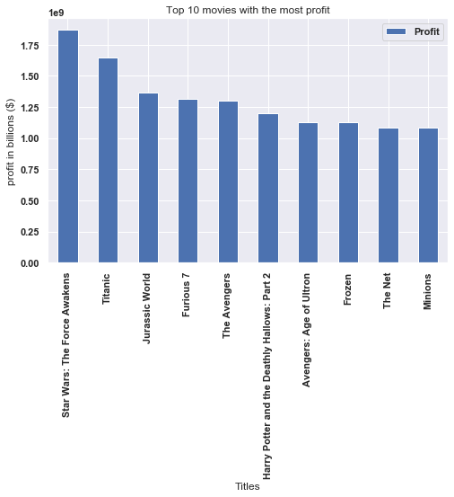

```python
# Create a bar graph for the top 10 most profitable movies


# First sort the raw data by the profit.
sorted_profit = df['profit'].sort_values(ascending=False)[:10]

# Create title and profit lists which will be used as X-axis and Y-axis values in bar graph.
high_profit=pd.DataFrame()
titles=[]
profit=[]

# Fill the vallues from raw data to the lists.
for i in sorted_profit.index:
    titles.append(df.loc[i,'original_title'])
    profit.append(sorted_profit.loc[i])
high_profit['Titles']=titles
high_profit['Profit']=profit
high_profit.set_index('Titles',inplace=True)

# Plot
high_profit.plot(kind ='bar',figsize=(8,5))
plt.title('Top 10 movies with the most profit');
plt.ylabel('profit in billions ($)');
sns.set_style('darkgrid')
```

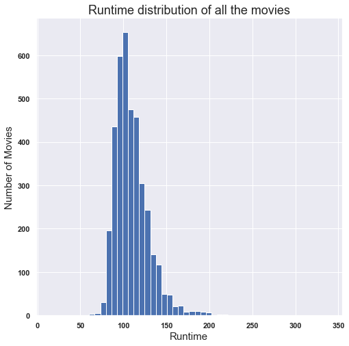

```python
# Create a histogram for movie runtimes.

df['runtime'].hist(figsize = (8,8), bins = 50)
plt.xlabel('Runtime', fontsize = 15)
plt.ylabel('Number of Movies', fontsize=15)
plt.title('Runtime distribution of all the movies', fontsize=18);
```

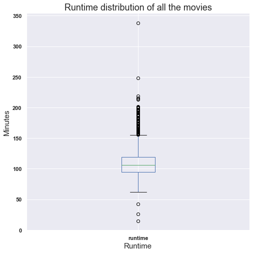

```python
# Box plot for Runtim.

df['runtime'].plot(kind = 'box', figsize = (8,8));
plt.ylabel('Minutes', fontsize=15)
plt.xlabel('Runtime', fontsize=15)
plt.title('Runtime distribution of all the movies', fontsize=18);
```

# Question 3. How does popularity affect the profit?

```
0.5552060524411401
```

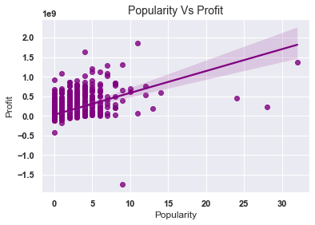

```python
# Create a scatter plot to study relationship between popularity and porfit.

ax = sns.regplot(x=df['popularity'],y=df['profit'],color='purple')

#setup the title and the labels of the scatter plot.
ax.set_title("Popularity Vs Profit",fontsize=14)
ax.set_xlabel("Popularity",fontsize=12)
ax.set_ylabel("Profit",fontsize=12)

#setup the figure size.
sns.set(rc={'figure.figsize':(6,4)})


def correlation_coeff(x,y):
    std_x=(x-x.mean())/x.std(ddof=0)
    std_y=(y-y.mean())/y.std(ddof=0)
    return(std_x*std_y).mean()

correlation_coeff(df['popularity'],df['profit'])
```

From the scatter plot, it can be concluded that there is a positive relationship between popularity and profit. The trend line is on a uphill direction and the correlation coefficient value is calculated to be positive. However, the lower correlation coefficient value is less desirable and is possibly due to movies with high budget and low profit and other similar situations.

# Question 4. Which years do movies made the most profits?

```python
# First group total profit by each years
profit_year = df.groupby('release_year')['profit'].sum()
profit_year.head(5)
```

```
release_year
1960    108198052.0
1961    299083188.0
1962    166879846.0
1963    115411882.0
1964    294678387.0
Name: profit, dtype: float64
```

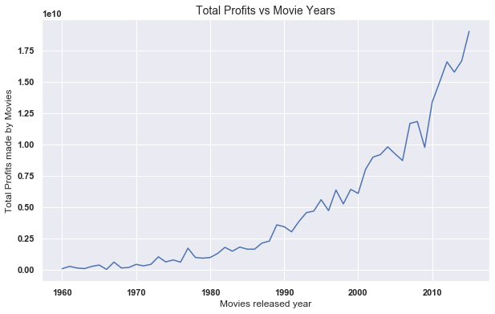

```python
# plot the above query.
profit_year.plot(figsize = (10,6))
plt.xlabel('Movies released year', fontsize = 12)
plt.ylabel('Total Profits made by Movies', fontsize = 12)
plt.title('Total Profits vs Movie Years', fontsize = 14);
```

Line plot will be useful when dealing with time and number. The plot shows that profits increases as years increases.

[figure not shown]

```python
# Do the same for the budget
budget_year = df.groupby('release_year')['budget'].sum()
budget_year.head(5)

# plot the above query
profit_year.plot(figsize = (10,6))
plt.xlabel('Movies released year', fontsize = 12)
plt.ylabel('Total budgets made by Movies', fontsize = 12)
plt.title('Total budgets vs Movie Years', fontsize = 14);
```

# Question 5. Average Runtime Of Movies From Year To Year?

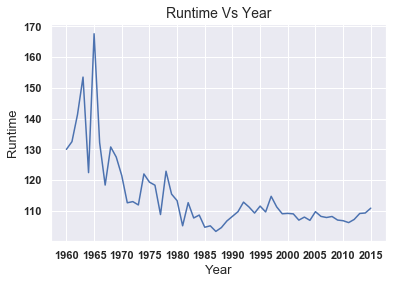

```python
df.groupby('release_year').mean()['runtime'].plot(xticks = np.arange(1960,2016,5))

#setup the figure size.
sns.set(rc={'figure.figsize':(10,5)})

#setup the title of the figure
plt.title("Runtime Vs Year",fontsize = 14)

#setup the x-label and y-label of the plot.
plt.xlabel('Year',fontsize = 13)
plt.ylabel('Runtime',fontsize = 13)
sns.set_style("whitegrid")
```